# Project 2: Data Mining, Classification, Prediction

SDS322E

# Mining, Classification, Prediction

## Brian Feng btf457

### Introduction

In project 1, I explored a Fortune 500 dataset and looked at how numerical variables (revenue, profit, etc) interacted with categorical variables (gender of ceo, experience of ceo, etc) and found some interesting correlations. Therefore, I decided to continue exploring with the Fortune dataset.

```r
library(tidyverse)
fortune <- read_csv("~/project2/Fortune_1000.csv")
top250 <- fortune[1:250, c(1:6, 11:13)]
names(top250)[6] <- "num_employees"
dim(top250)
```

```
## [1] 250   9
```

```r
top250 %>% count(ceo_founder)
```

```
## # A tibble: 2 x 2
##   ceo_founder     n
##   <chr>       <int>
## 1 no            241
## 2 yes             9
```

```r
top250 %>% count(ceo_woman)
```

```
## # A tibble: 2 x 2
##   ceo_woman     n
##   <chr>     <int>
## 1 no          229
## 2 yes          21
```

```r
top250 %>% count(profitable)
```

```
## # A tibble: 2 x 2
##   profitable     n
##   <chr>      <int>
## 1 no            25
## 2 yes          225
```

Because we are running through large amounts of data, and the R silhouette package can only handle a certain amount of data, I decided to cut down the dataset and only look at the Fortune top 250 companies. Further, I decided to shorten the number of columns and only look at the following variables: “company”, “rank”, “rank_change”, “revenue”, “profit”, “num_employees”, “ceo_founder”, ceo_woman“,”profitable“. The last 3 variables ceo_founder, ceo_woman, and profitable are all binary variables with”yes" and “no” answers. The number of observations per group are ceo_founder(yes: 9/no: 241), ceo_woman(yes: 21/no: 229), and profitable(yes: 225/no: 25). While the rest are all numerical variables. The dataset has a total of 250 rows and 9 columns. Further details on the variables and how they were collected can be found at: https://www.kaggle.com/winston56/fortune-500-data-2021

### Cluster Analysis

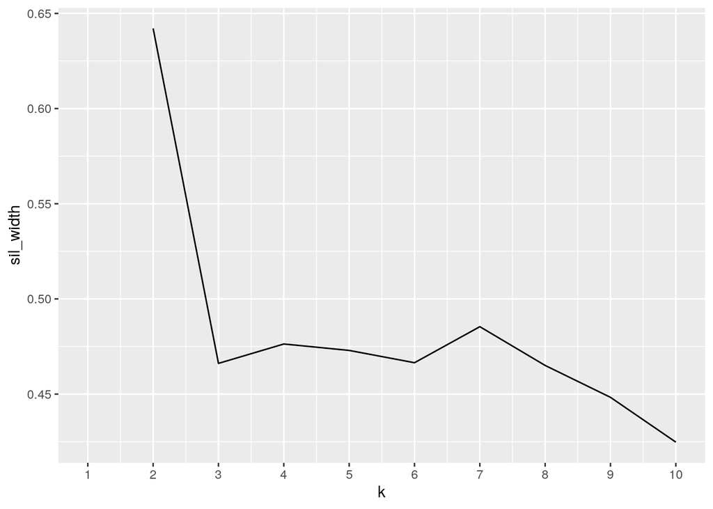

```r
library(cluster)
test <- top250 %>% mutate_if(is.character, as.factor) %>% column_to_rownames("company") %>%
    daisy("gower") %>% as.matrix
gower1 <- daisy(test, metric = "gower")  #here they are!

sil_width <- vector()
for (i in 2:10) {
    pam_fit <- pam(gower1, diss = TRUE, k = i)
    sil_width[i] <- pam_fit$silinfo$avg.width
}
ggplot() + geom_line(aes(x = 1:10, y = sil_width)) + scale_x_continuous(name = "k",
    breaks = 1:10)
```

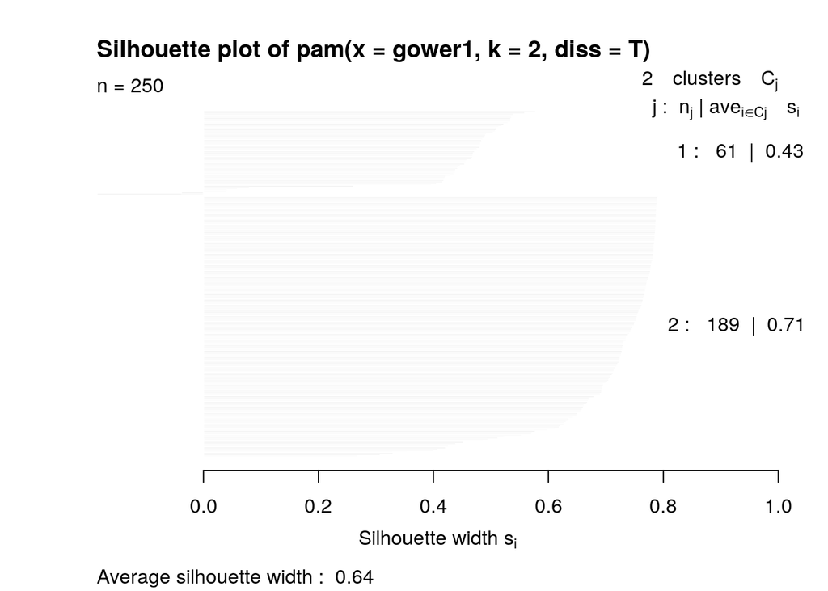

```r
pam <- pam(gower1, k = 2, diss = T)  #tell pam you are using dissimilarities
plot(pam, which = 2, color = "dark blue")
```

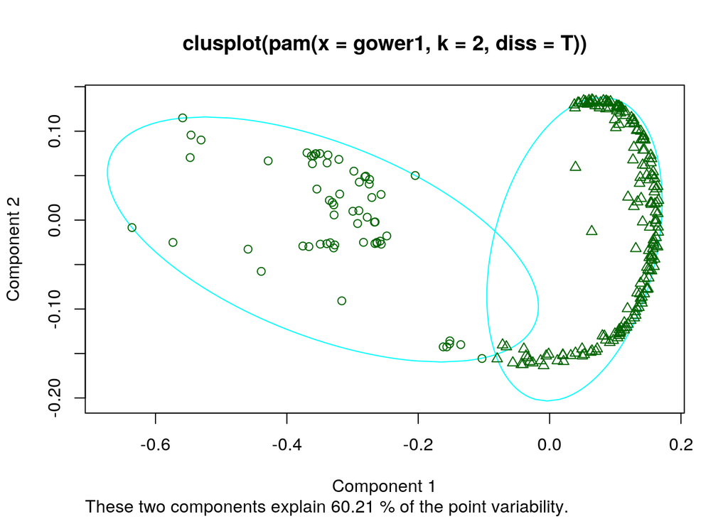

```r
plot(pam, which = 1)
```

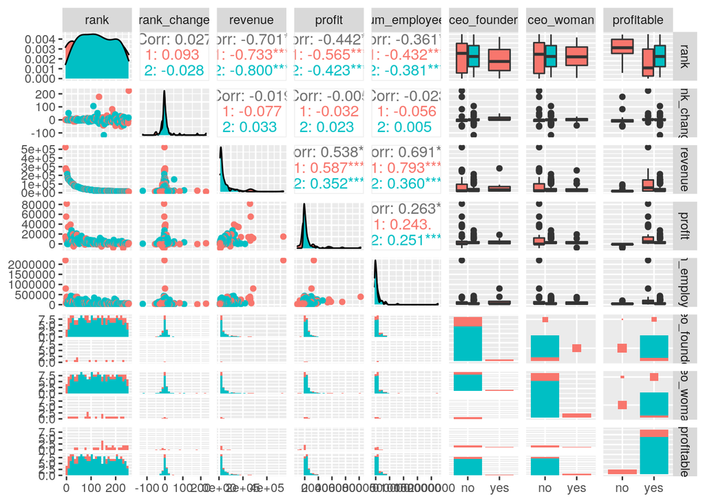

```r
library(GGally)
ggpairs(top250, columns = 2:9, aes(color = as.factor(pam$clustering)))
```

The clustering is done based on gower dissimilarities. Running through a for-loop, we find out that the largest average silhouette width is with 2 clusters. When clustering with 2 clusters the average silhouette width is 0.64 which suggests that a reasonable structure has been identified. From the ggpairs plot, we can tell that the most correlated two variables are number of employees with revenue (positive) and revenue with rank(negative). However, overall, there isn’t one variable that particularly well explains the two clusters.

### Dimensionality Reduction with PCA

```r
top250_nums <- top250 %>% select_if(is.numeric) %>% scale
rownames(top250_nums) <- top250$company
top250_pca <- princomp(top250_nums, cor = T)
summary(top250_pca, loadings = T)
```

```
## Importance of components:
##                           Comp.1    Comp.2    Comp.3    Comp.4     Comp.5
## Standard deviation     1.5909791 0.9998571 0.8744778 0.7351623 0.40484092
## Proportion of Variance 0.5062429 0.1999428 0.1529423 0.1080927 0.03277923
## Cumulative Proportion  0.5062429 0.7061858 0.8591280 0.9672208 1.00000000
##
## Loadings:
##               Comp.1 Comp.2 Comp.3 Comp.4 Comp.5
## rank           0.503         0.228  0.738  0.388
## rank_change          -0.999
## revenue       -0.590         0.133         0.794
## profit        -0.432        -0.661  0.588 -0.169
## num_employees -0.460         0.702  0.326 -0.436
```

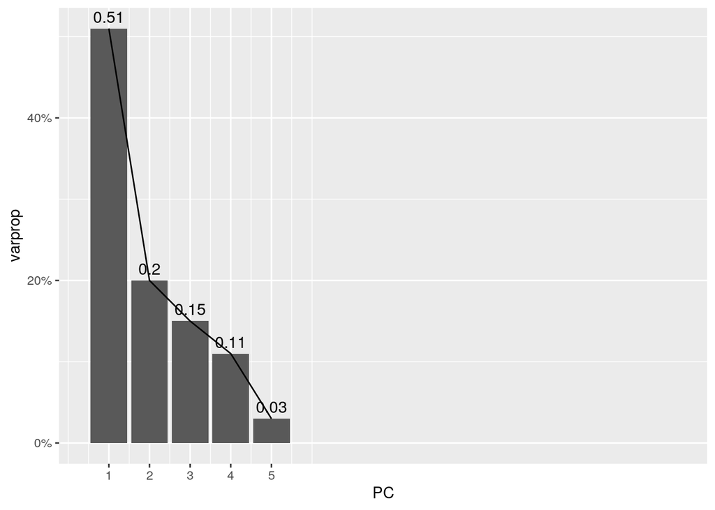

```r
eigval <- top250_pca$sdev^2  #square to convert SDs to eigenvalues
varprop = round(eigval/sum(eigval), 2)  #proportion of var explained by each PC
ggplot() + geom_bar(aes(y = varprop, x = 1:5), stat = "identity") +
    xlab("PC") + geom_path(aes(y = varprop, x = 1:5)) + geom_text(aes(x = 1:5,
    y = varprop, label = round(varprop, 2)), vjust = -0.5, size = 4) +
    scale_y_continuous(breaks = seq(0, 0.6, 0.2), labels = scales::percent) +
    scale_x_continuous(breaks = 1:5, limits = c(0.5, 15))
```

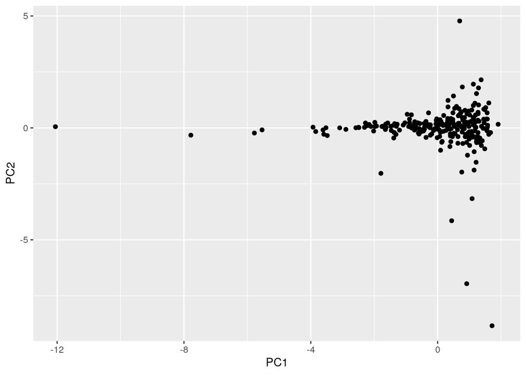

```r
df <- data.frame(PC1 = top250_pca$scores[, 1], PC2 = top250_pca$scores[,
    2], PC3 = top250_pca$scores[, 3])
ggplot(df, aes(PC1, PC2)) + geom_point()
```

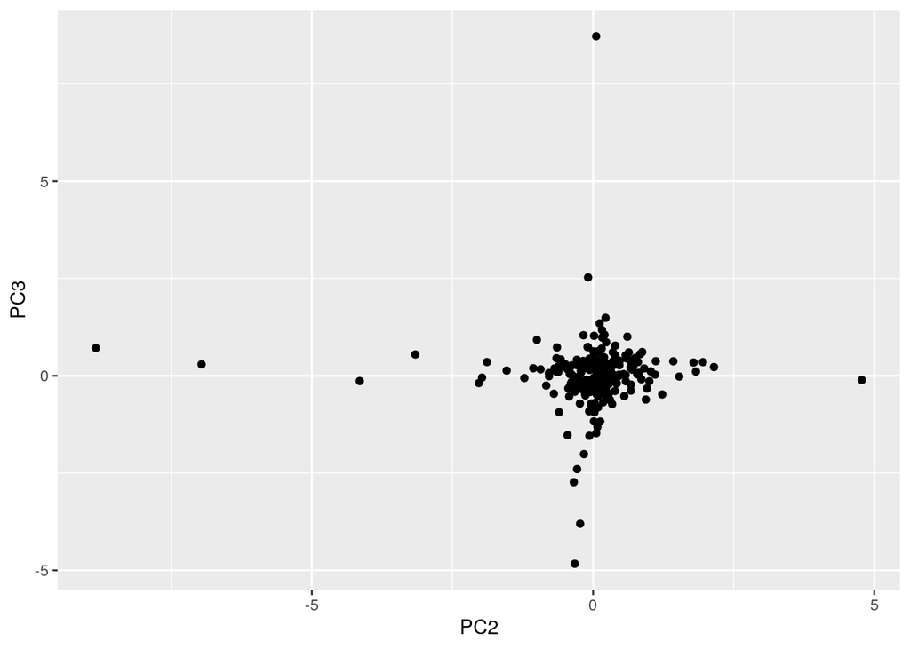

```r
ggplot(df, aes(PC2, PC3)) + geom_point()
```

### Linear Classifier

```r
logistic_fit <- glm(profitable == "yes" ~ rank + revenue + num_employees,
    data = top250, family = "binomial")
prob_reg <- predict(logistic_fit, type = "response")
class_diag(prob_reg, top250$profitable == "yes", positive = TRUE)
```

```
##         acc sens spec ppv     f1  ba    auc
## Metrics 0.9    1    0 0.9 0.9474 0.5 0.6976
```

We are predicting the binary variable of whether a company is profitable based on the numerical variables of revenue, number of employees, and the rank. The AUC is 0.6976 so it is in the “Poor” range of 0.6~0.7. It is really close to the “Fair” range of 0.7~0.8.

```r
table(truth = factor(top250$profitable == "yes", levels = c("TRUE",
    "FALSE")), prediction = factor(prob_reg > 0.5, levels = c("TRUE",
    "FALSE")))
```

```
##        prediction
## truth   TRUE FALSE
##   TRUE   225     0
##   FALSE   25     0
```

```r
set.seed(3)

k = 10

data <- sample_frac(top250)  #randomly order rows
folds <- rep(1:k, length.out = nrow(data))  #create folds

diags <- NULL

i = 1
for (i in 1:k) {
    # create training and test sets
    train <- data[folds != i, ]
    test <- data[folds == i, ]
    truth <- test$profitable
    # train model
    logistic_fit <- glm(profitable == "yes" ~ rank + revenue +
        num_employees, data = train, family = "binomial")
    # test model
    probs <- predict(logistic_fit, test, type = "response")
    # get performance metrics for each fold
    diags <- rbind(diags, class_diag(probs, truth, positive = "yes"))
}
# average performance metrics across all folds
summarize_all(diags, mean)
```

```
##   acc sens spec ppv      f1  ba     auc
## 1 0.9    1    0 0.9 0.94687 0.5 0.71109
```

The AUC for our CV is 0.71109 so it is in the “Fair” range of 0.7~0.8. This AUC score went up from the 0.6976 from the previous AUC score so there are no signs of overfitting in our model.

### Non-Parametric Classifier

```r
library(caret)
knn_fit <- knn3(factor(profitable == "yes", levels = c("TRUE",
    "FALSE")) ~ rank + revenue + num_employees, data = top250,
    k = 5)
y_hat_knn <- predict(knn_fit, top250)
class_diag(y_hat_knn[, 1], top250$profitable, positive = "yes")
```

```
##           acc   sens spec    ppv     f1     ba   auc
## Metrics 0.908 0.9867  0.2 0.9174 0.9507 0.5933 0.916
```

We are performing knn on the same dataset as the previous section, that is, we are predicting the binary variable of whether a company is profitable based on the numerical variables of revenue, number of employees, and the rank. The AUC is 0.916 so it is in the “Great!” range of 0.9~1.0.

```r
table(truth = factor(top250$profitable == "yes", levels = c("TRUE",
    "FALSE")), prediction = factor(y_hat_knn[, 1] > 0.5, levels = c("TRUE",
    "FALSE")))
```

```
##        prediction
## truth   TRUE FALSE
##   TRUE   222     3
##   FALSE   20     5
```

```r
set.seed(3)
k = 10

data <- sample_frac(top250)  #randomly order rows
folds <- rep(1:k, length.out = nrow(data))  #create folds

diags <- NULL

i = 1
for (i in 1:k) {
    # create training and test sets
    train <- data[folds != i, ]
    test <- data[folds == i, ]
    truth <- test$profitable

    # train model
    fit <- knn3(profitable == "yes" ~ rank + revenue + num_employees,
        data = train)
    # test model
    probs <- predict(fit, newdata = test)[, 2]

    # get performance metrics for each fold
    diags <- rbind(diags, class_diag(probs, truth, positive = "yes"))
}

# average performance metrics across all folds
summarize_all(diags, mean)
```

```
##   acc    sens    spec     ppv      f1      ba     auc
## 1 0.9 0.98278 0.14166 0.91366 0.94623 0.56225 0.67904
```

### Regression/Numeric Prediction

```r
numeric <- top250 %>% select_if(is.numeric)
fit <- lm(rank_change ~ ., data = numeric)
yhat <- predict(fit)
mean((numeric$rank_change - yhat)^2)
```

```
## [1] 624.5297
```

The Mean Squared Error for the numerical variable rank_change is 624.5297.

```r
set.seed(3)
k = 5  #choose number of folds
data <- numeric[sample(nrow(numeric)), ]  #randomly order rows
folds <- cut(seq(1:nrow(numeric)), breaks = k, labels = F)  #create folds
diags <- NULL
for (i in 1:k) {
    train <- data[folds != i, ]
    test <- data[folds == i, ]
    ## Fit linear regression model to training set
    fit <- lm(rank_change ~ ., data = train)
    ## Get predictions/y-hats on test set (fold i)
    yhat <- predict(fit, newdata = test)
    ## Compute prediction error (MSE) for fold i
    diags <- mean((test$rank_change - yhat)^2)
}
mean(diags)
```

```
## [1] 1033.458
```

### Python

```r
library(reticulate)
```

```python
top = r.top250
print(type(top))
```

```
## <class 'dict'>
```

```python
print(type(top["rank"]))
```

```
## <class 'list'>
```

```python
python = "this is project2"
```

```r
py$python
```

```
## [1] "this is project2"
```

Through “r.” we were able to use Python’s type and print function on the R dataset “top250” and find out that the r data frame is converted to a dictionary in Python. Through the “py$” we were able to call the python object in R and print out the line “this is project2”.

### Concluding Remarks

I had a lot of fun this semester and am really glad I got to work on an interesting project like this one to finish the semester!